# L3 Drawdowns

FIN 3380

Week 8-9

```r
setwd("C:/Users/siche/Documents/teaching/Introduction to Financial Data Analysis/L3/")
library(zoo)
library(tidyr)
library(dplyr)
```

```r
library(ggplot2)
```

# SSE Composite Index Drawdown

## Step 1. load data and visualize the historical performance of returns of SH Composite Index

```r
sh1 = read.csv("SH000001.csv")
head(sh1)
```

```
##     Month Clsidx    Idxrtn
## 1 1990-12 127.61  0.000000
## 2 1991-01 129.97  0.018494
## 3 1991-02 133.01  0.023390
## 4 1991-03 120.19 -0.096384
## 5 1991-04 113.94 -0.052001
## 6 1991-05 114.83  0.007811
```

```r
tail(sh1)
```

```
##       Month  Clsidx    Idxrtn
## 341 2019-04 3078.34 -0.004018
## 342 2019-05 2898.70 -0.058357
## 343 2019-06 2978.88  0.027661
## 344 2019-07 2932.51 -0.015567
## 345 2019-08 2886.24 -0.015778
## 346 2019-09 2905.19  0.006566
```

```r
summary(sh1)
```

```
##      Month         Clsidx           Idxrtn
##  1990-12:  1   Min.   : 113.9   Min.   :-0.311529
##  1991-01:  1   1st Qu.:1167.2   1st Qu.:-0.047020
##  1991-02:  1   Median :1782.5   Median : 0.006366
##  1991-03:  1   Mean   :1943.3   Mean   : 0.017625
##  1991-04:  1   3rd Qu.:2757.4   3rd Qu.: 0.052016
##  1991-05:  1   Max.   :5954.8   Max.   : 1.772262
##  (Other):340
```

```r
# Check the potential error in data (huge return)
sh1[(which(sh1$Idxrtn==max(sh1$Idxrtn))-2): (which(sh1$Idxrtn==max(sh1$Idxrtn))+2),]
```

```
##      Month  Clsidx    Idxrtn
## 16 1992-03  381.24  0.045467
## 17 1992-04  445.38  0.168240
## 18 1992-05 1234.71  1.772262
## 19 1992-06 1191.19 -0.035247
## 20 1992-07 1052.07 -0.116791
```

```r
sh1$Month = as.yearmon(sh1$Month)
colnames(sh1) = c("date","idx","ret")
head(sh1)
```

```
##       date    idx       ret
## 1 Dec 1990 127.61  0.000000
## 2 Jan 1991 129.97  0.018494
## 3 Feb 1991 133.01  0.023390
## 4 Mar 1991 120.19 -0.096384
## 5 Apr 1991 113.94 -0.052001
## 6 May 1991 114.83  0.007811
```

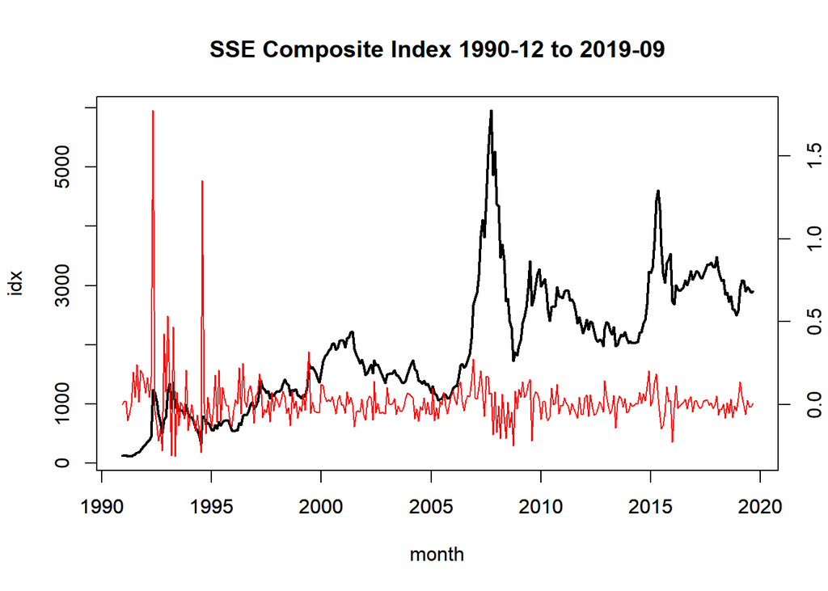

```r
plot(sh1$idx~sh1$date,type='l',
     lwd=2,xlab='month',ylab='idx',main='SSE Composite Index 1990-12 to 2019-09')
par(new=T)
plot(sh1$ret~sh1$date,type='l',col='red',
     xlab='',ylab='',yaxt='n')
axis(4)
```

## Step 2. Calculate the drawdowns

- Use function cummax() from base R to calculate the cumulative maxima of a vector
- Drawdown(t) = (Price_t-Cummax_t)/Cummax_t

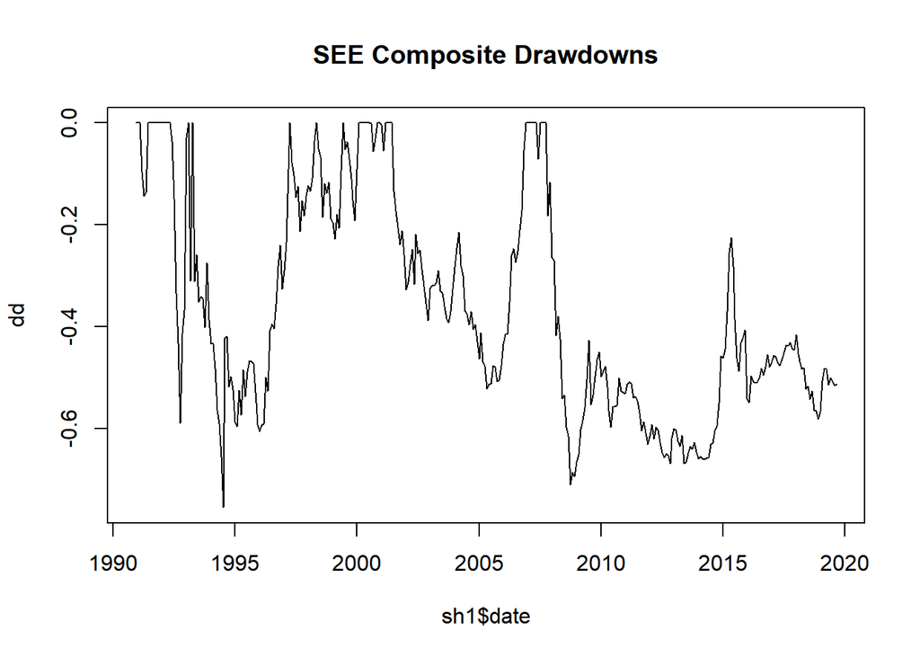

```r
sh1$dd = (sh1$idx-cummax(sh1$idx))/cummax(sh1$idx)
plot(sh1$dd~sh1$date,type='l',ylab='dd',main='SEE Composite Drawdowns')
```

- Drawdowns are always negative numbers as it measures the difference between peak and current level
- At each point, if the line is below zero, the current level of the index is below its previous high-water mark.
- The wider the area before the line rehit the zero line, the longer the period of staying in loss from previous peak.

## Step 3. Summarize the drawdowns

### The maximum drawdown

```r
dd.max = max(-sh1$dd)
dd.max
```

```
## [1] 0.7542501
```

### The longest period in drawdown

- Mark the dates of drawdowns by 1 and rest by 0. Count the length of sequence of 1s.
- rle() from base R Compute the lengths and values of runs of equal values in a vector – or the reverse operation.

```r
sh1$dd = round(sh1$dd,4)
sh1 = sh1 %>% mutate(dd.flag = ifelse(dd<0,1,0))
head(sh1)
```

```
##       date    idx       ret      dd dd.flag
## 1 Dec 1990 127.61  0.000000  0.0000       0
## 2 Jan 1991 129.97  0.018494  0.0000       0
## 3 Feb 1991 133.01  0.023390  0.0000       0
## 4 Mar 1991 120.19 -0.096384 -0.0964       1
## 5 Apr 1991 113.94 -0.052001 -0.1434       1
## 6 May 1991 114.83  0.007811 -0.1367       1
```

```r
v = c(1,1,1,0,0,1,1,1,0,0,0,1)
rles = rle(v)
rles
```

```
## Run Length Encoding
##   lengths: int [1:5] 3 2 3 3 1
##   values : num [1:5] 1 0 1 0 1
```

```r
inverse.rle(rles)
```

```
##  [1] 1 1 1 0 0 1 1 1 0 0 0 1
```

```r
rles = rle(v==1)
rles
```

```
## Run Length Encoding
##   lengths: int [1:5] 3 2 3 3 1
##   values : logi [1:5] TRUE FALSE TRUE FALSE TRUE
```

```r
max(rles$lengths[rles$values==T])
```

```
## [1] 3
```

```r
rles = rle(sh1$dd.flag==1)
summary(rles$lengths[rles$values==T])/12
```

```
##     Min.  1st Qu.   Median     Mean  3rd Qu.     Max.
##  0.08333  0.22917  0.62500  2.11111  1.72917 11.91667
```

- The longest drawdown period is about 12 years.
- The average drawdown period is 2 years with median less than 1 year.

## Step 4. Calmar Ratio

- Calmar Ratio = Average Annual Rate of Return / Maximum Drawdown

```r
mean(sh1$ret*12)/dd.max
```

```
## [1] 0.280411
```

# Co-drawdown of Bond and Equity

## Step 1. Load the 10-year treasury bond and sp500 data from L2 and reformat date

```r
load("C:/Users/siche/Documents/teaching/Introduction to Financial Data Analysis/L2/eq.bond.RData")
eq.bond = eq.bond[,c("date","sp500","bond10y")]
eq.bond$date = as.Date(eq.bond$date)
```

## Step 2. Calculate the cumulative returns of sp500 and 10year bond, using them as the level of index

- mutate_at(vars(columnnames),list(rst = function(.))) from dplyr affects variables selected within vars()

```r
eq.bond = eq.bond %>%
  mutate_at(vars(sp500,bond10y),
            list(cumret = function(x) cumprod(x+1)))
head(eq.bond)
```

```
##         date      sp500    bond10y sp500_cumret bond10y_cumret
## 1 1962-03-31 -0.0054600  0.0127560    0.9945400       1.012756
## 2 1962-04-30 -0.0608186  0.0018875    0.9340535       1.014668
## 3 1962-05-31 -0.0843448 -0.0010309    0.8552709       1.013622
## 4 1962-06-30 -0.0781284 -0.0041314    0.7884500       1.009434
## 5 1962-07-31  0.0662528 -0.0001259    0.8406870       1.009307
## 6 1962-08-31  0.0161290  0.0079269    0.8542464       1.017307
```

```r
# alternatively, use ~cumprod(.+1), ~ is equivalent to function(x)

eq.bond = eq.bond %>%
  mutate_at(vars(sp500,bond10y),
            list(cumret = ~cumprod(.+1)))
head(eq.bond)
```

```
##         date      sp500    bond10y sp500_cumret bond10y_cumret
## 1 1962-03-31 -0.0054600  0.0127560    0.9945400       1.012756
## 2 1962-04-30 -0.0608186  0.0018875    0.9340535       1.014668
## 3 1962-05-31 -0.0843448 -0.0010309    0.8552709       1.013622
## 4 1962-06-30 -0.0781284 -0.0041314    0.7884500       1.009434
## 5 1962-07-31  0.0662528 -0.0001259    0.8406870       1.009307
## 6 1962-08-31  0.0161290  0.0079269    0.8542464       1.017307
```

- keep yearly data only, using format to extract year from date
- summarise_at(vars(),list(rst = function(.)))

```r
eq.bond = eq.bond %>%
  mutate(year = format(date,"%Y")) %>%
  group_by(year) %>%
  summarise_at(vars(sp500_cumret,bond10y_cumret),list(~last(.))) %>%
  ungroup()

head(eq.bond)
```

```
## # A tibble: 6 x 3
##   year  sp500_cumret bond10y_cumret
##   <chr>        <dbl>          <dbl>
## 1 1962         0.920          1.04
## 2 1963         1.11           1.04
## 3 1964         1.28           1.06
## 4 1965         1.41           1.05
## 5 1966         1.23           1.07
## 6 1967         1.47           0.999
```

## Step 3. Calculate drawdowns of each individual asset and visualise their drawdowns

```r
eq.bond = eq.bond %>%
  mutate_at(vars(sp500_cumret,bond10y_cumret),
            list(dd = function(x) (x-cummax(x))/cummax(x)))

# alternatively use ~ to represent function(x)

eq.bond = eq.bond %>%
  mutate_at(vars(sp500_cumret,bond10y_cumret),
            list(dd = ~(.-cummax(.))/cummax(.)))

head(eq.bond)
```

```
## # A tibble: 6 x 5
##   year  sp500_cumret bond10y_cumret sp500_cumret_dd bond10y_cumret_dd
##   <chr>        <dbl>          <dbl>           <dbl>             <dbl>
## 1 1962         0.920          1.04            0              0
## 2 1963         1.11           1.04            0             -0.000442
## 3 1964         1.28           1.06            0              0
## 4 1965         1.41           1.05            0             -0.0119
## 5 1966         1.23           1.07           -0.130          0
## 6 1967         1.47           0.999           0             -0.0626
```

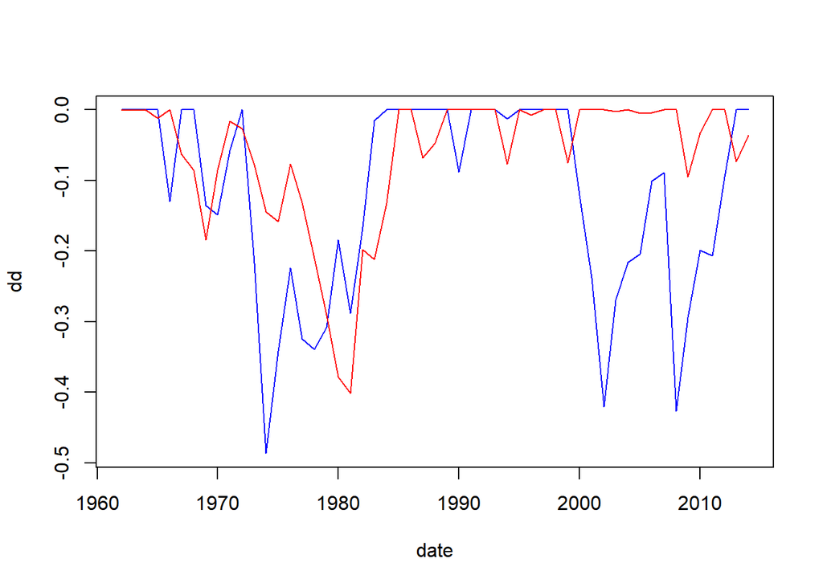

```r
plot(eq.bond$sp500_cumret_dd~eq.bond$year,type='l',
     xlab = 'date',ylab ='dd',col='blue')
lines(eq.bond$bond10y_cumret_dd~eq.bond$year,col='red')
```

## Step 4. Calculate the total area under water

- pmax() and pmin() take one or more vectors as arguments, recycle them to common length and return a single vector giving the ‘parallel’ maxima (or minima) of the argument vectors.

```r
min(c(1,2,3),c(2,1,3))
```

```
## [1] 1
```

```r
pmin(c(1,2,3),c(2,1,3))
```

```
## [1] 1 1 3
```

```r
eq.bond = eq.bond %>%
  mutate(anydown = pmin(sp500_cumret_dd,bond10y_cumret_dd))
head(eq.bond)
```

```
## # A tibble: 6 x 6
##   year  sp500_cumret bond10y_cumret sp500_cumret_dd bond10y_cumret_~
##   <chr>        <dbl>          <dbl>           <dbl>            <dbl>
## 1 1962         0.920          1.04            0             0
## 2 1963         1.11           1.04            0            -0.000442
## 3 1964         1.28           1.06            0             0
## 4 1965         1.41           1.05            0            -0.0119
## 5 1966         1.23           1.07           -0.130         0
## 6 1967         1.47           0.999           0            -0.0626
## # ... with 1 more variable: anydown <dbl>
```

## Step 5. Calculate the the total area when both assets are under water.

```r
eq.bond = eq.bond %>%
  mutate(codown = pmax(sp500_cumret_dd,bond10y_cumret_dd))

head(eq.bond)
```

```
## # A tibble: 6 x 7
##   year  sp500_cumret bond10y_cumret sp500_cumret_dd bond10y_cumret_~
##   <chr>        <dbl>          <dbl>           <dbl>            <dbl>
## 1 1962         0.920          1.04            0             0
## 2 1963         1.11           1.04            0            -0.000442
## 3 1964         1.28           1.06            0             0
## 4 1965         1.41           1.05            0            -0.0119
## 5 1966         1.23           1.07           -0.130         0
## 6 1967         1.47           0.999           0            -0.0626
## # ... with 2 more variables: anydown <dbl>, codown <dbl>
```

## Step 6. Visualize the co-drawdown

- polygon(c(x,rev(x)),c(ymin,ymax)) to shade an area beween ymin and ymax
- with(data, expr, …) function allows us to perform an action on dataframe columns without specified the dataframe name every time, and we can also omit "" when quote a field in a dataframe

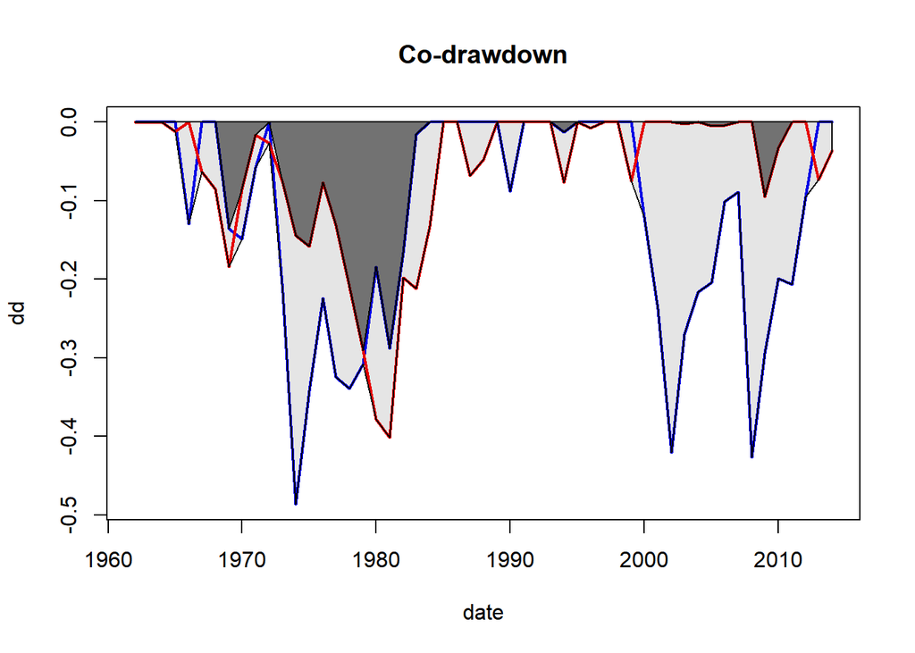

```r
eq.bond$zeroline = 0

plot(eq.bond$sp500_cumret_dd~eq.bond$year,
     type='l', lwd = 2, col = 'blue',
     xlab = 'date',ylab ='dd',
     main='Co-drawdown')

lines(eq.bond$bond10y_cumret_dd~eq.bond$year,
      lwd = 2,
      col='red')

with(eq.bond,
     polygon(c(year,rev(year)),
             c(zeroline,rev(anydown)),
             col=rgb(0, 0, 0, 0.1)))

with(eq.bond,
     polygon(c(year,rev(year)),
             c(zeroline,rev(codown)),
             col=rgb(0, 0, 0, 0.5)))
```

# Step 7. Calculate the probability of co-drawdown

```r
codd = sum(eq.bond$codown)/sum(eq.bond$anydown)
codd
```

```
## [1] 0.2795537
```

- The co-drawdown in the 1970s are due to a couple of events: collapse of the Bretton Woods system, oil crisis.
- Bonds are relatively safe asset in the other two big crisis, the dot.com bubble burst and the Great Recession in 2008.